# Simulate of Exponential Distribution

Tony

# Overview :

We will simulate how means/sd/variance of exponential distribution random samples behave like normal distribution

# Simulation

Generate 1000x40 number of exponential random number using rate=.2 store the raw data in expdata. Store the 1000 means of each 40 samples in expmeans. Store the 1000 variances of each 40 samples in expVars. Store the 1000 standard deviation of each 40 samples in expSDs.

```r
expdata <- matrix(nrow=1000, ncol=40)
expmeans <- expVars <- expSDs <- c(rep(NULL, t))
for (i in 1:1000)  {
        expdata[i,] <- rexp(40, .2)
        expmeans[i] <- mean(expdata[i,])
        expVars[i] <- var(expdata[i,])
        expSDs[i] <- sd(expdata[i,])
}
```

# Sample Mean versus Theoretical Mean :

Histogram of the sample data is as below. We hightlight the theoretical mean using **red** vertical line (5 = 1/lambda = 1/.2). Also the **blue** vertical line is the mean of the sample data = 5.0427153.You can see that mean of the sample data is almost the same as theoretical mean.

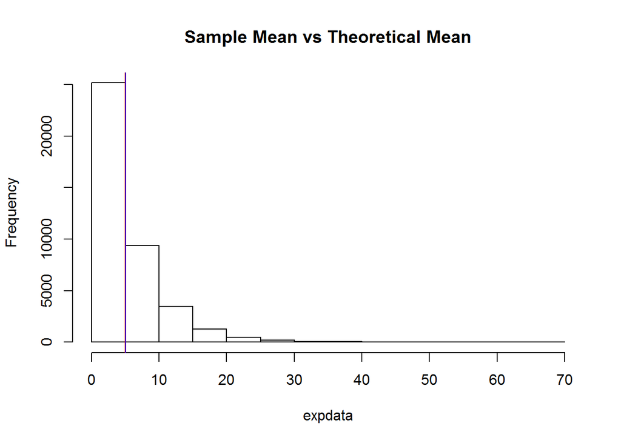

# Sample Variance versus Theoretical Variance:

Let’s see the histogram of the 1000 variances of the sample data. Also we hightlight the theoretical variance (25) with **red** vertical line. It’s close to the normal distribution with a little skewness.

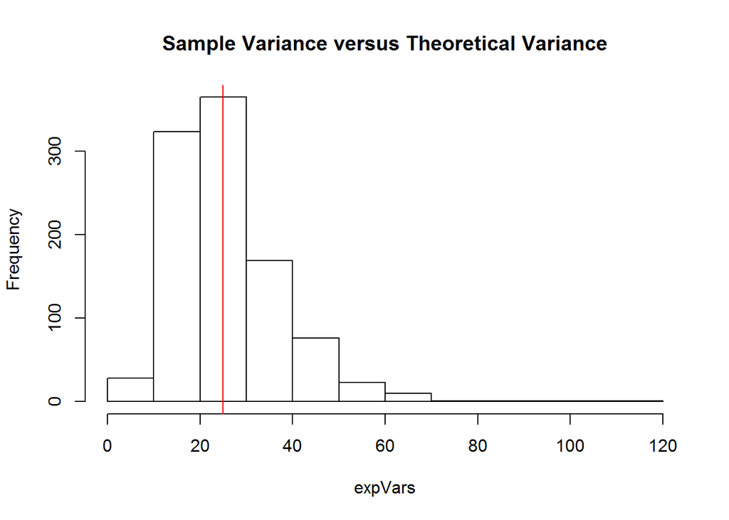

# Distribution :

Lastly, we can see the distribution of the means is close to normal distribution by ploting the histogram of the 1000 means. Although the sample data is from exponential distribution. This is the Central Limit Theory. The vertical red line is the theoretical mean (1/.2 = 5)

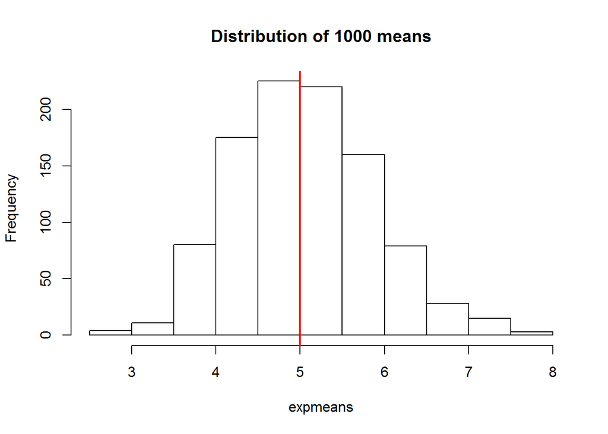